# Barbell Lifts prediction

# Anaylsis of correct excuction of Barebell lifts

## Intrduction

The objective of this anaylsisis to predict if a barebell lift is executed correctly or if there were some mistakes during execution.

Provided is a set of nearly 20,000 observation in 160 variable, which can be found here: https://d396qusza40orc.cloudfront.net/predmachlearn/pml-training.csv and is provided by: http://groupware.les.inf.puc-rio.br/har Also a test set woth 20 observation was provided: https://d396qusza40orc.cloudfront.net/predmachlearn/pml-testing.csv

# Setup environment and Load data

For this assignment the Caret package is used. The Caret package also loads ggplot2 and lattice which helps with the graphical Analysis of data.

Machine Learning can be quite time consuming therefore also doParallel package is used to speed up learning phase.

# Data Preparation

Viewing data shows that there are some columns which mainly consists of “NA” and empty values. Those data cannot contribute to the result but comsume time during training. Only those variables are used which contribute to at least half of all results

Also all factor variables which are not coming from sensors arte cleaned

```r
cleanNA <- as.vector(apply(trainingData,2,function(x) min(length(which(!is.na(x))))))
clean1 <- trainingData[,cleanNA > (nrow(trainingData)/2)]
cleanEmpty <- as.vector(apply(clean1,2,function(x) nrow(clean1) - sum(x == "")))
clean2 <- clean1[,cleanEmpty > (nrow(trainingData)/2)]
clean <- clean2[,c(-1,-2,-3,-4,-5,-6,-7,-8)]
```

Find and remove highly correlated varaibles to avoid that the same underlying fact is used several times.

```r
corTrain <- cor(clean[,-(length(clean))])
corFind <- findCorrelation(corTrain,cutoff = .9, verbose=FALSE)
clean <- clean[,-corFind]
```

Now let inspect the variable and their relationship to the outcome visually, which is not easy with 46 varaibale.

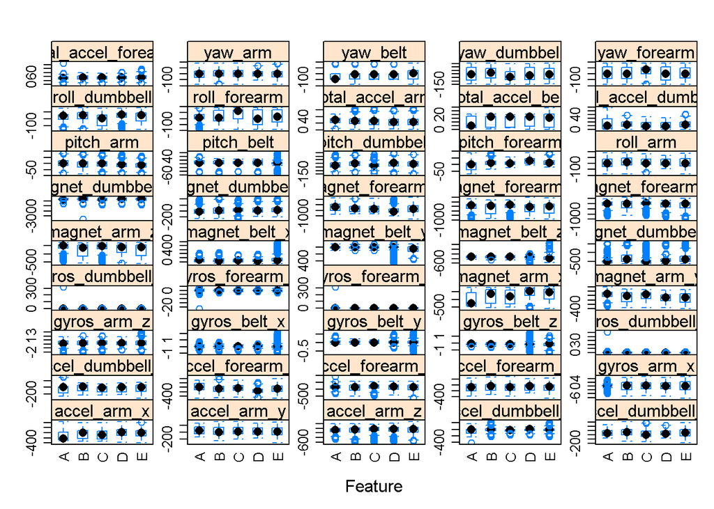

```r
featurePlot(x = clean[,-length(clean)], y = clean$classe, plot = "box",
                      scales = list(y = list(relation="free"), x = list(rot = 90)),
                      layout = c(5,9 ))
```

Some variables shows an indication of certain classes, e.g. if accel_arm_x is low than it seems to be related to classe ‘A’, but there is no obvious variable which can do the prediction. Important to note is that the variables seems to be more or less balanced. This will allow to use random forrests

# Prepare Cross validation

```r
  inTrain <- createDataPartition(y=clean$classe,p=0.3,list=FALSE)
  training <- clean[inTrain,]
  test <- clean[-inTrain,]
```

# Train the model

Random tree is not biased. To speed up model fitting Parallel execution is used

```r
  registerDoParallel(4,cores=4)
  getDoParWorkers()
```

```
## [1] 4
```

```r
  modelFit <- train(classe ~.,data=training,method="rf",prox=TRUE)
```

Check the importance of variables

```r
varImp(modelFit)
```

```
## rf variable importance
##
##   only 20 most important variables shown (out of 45)
##
##                      Overall
## yaw_belt               100.0
## pitch_forearm           85.1
## magnet_dumbbell_z       69.3
## pitch_belt              64.7
## magnet_dumbbell_y       48.2
## magnet_belt_y           48.1
## roll_forearm            41.7
## gyros_belt_z            32.9
## magnet_belt_z           30.8
## roll_dumbbell           28.0
## magnet_dumbbell_x       24.4
## accel_forearm_x         24.4
## accel_dumbbell_y        22.6
## magnet_belt_x           19.6
## accel_forearm_z         18.8
## accel_dumbbell_z        18.3
## magnet_forearm_z        16.0
## total_accel_dumbbell    15.9
## total_accel_belt        15.7
## roll_arm                12.6
```

# Predicting data and validation

First predict on the data saved for Cross validation.

```r
  pred <- predict(modelFit,test)
```

Checking the confusion matrix to determine out of sample error

```r
  cm <- confusionMatrix(pred,test$classe)
  cm
```

```
## Confusion Matrix and Statistics
##
##           Reference
## Prediction    A    B    C    D    E
##          A 3891   53    0    4    0
##          B    1 2566   42    0    3
##          C    6   28 2335   54    8
##          D    6   10   16 2188   19
##          E    2    0    2    5 2494
##
## Overall Statistics
##
##                Accuracy : 0.981
##                  95% CI : (0.979, 0.983)
##     No Information Rate : 0.284
##     P-Value [Acc > NIR] : <2e-16
##
##                   Kappa : 0.976
##  Mcnemar's Test P-Value : <2e-16
##
## Statistics by Class:
##
##                      Class: A Class: B Class: C Class: D Class: E
## Sensitivity             0.996    0.966    0.975    0.972    0.988
## Specificity             0.994    0.996    0.992    0.996    0.999
## Pos Pred Value          0.986    0.982    0.961    0.977    0.996
## Neg Pred Value          0.998    0.992    0.995    0.995    0.997
## Prevalence              0.284    0.193    0.174    0.164    0.184
## Detection Rate          0.283    0.187    0.170    0.159    0.182
## Detection Prevalence    0.287    0.190    0.177    0.163    0.182
## Balanced Accuracy       0.995    0.981    0.983    0.984    0.994
```

```r
s <- sum(cm$table)
c <- cm$table[1,1] + cm$table[2,2] + cm$table[3,3] +cm$table[4,4] + cm$table[5,5]
s/c
```

```
## [1] 1.019
```

# Final test prediction

Now let’s run the final test.

```r
predTest <- predict(modelFit,testingData)
predTest
```

```
##  [1] B A B A A E D B A A B C B A E E A B B B
## Levels: A B C D E
```